# ベイズ推論モデルの基礎と計算論的精神医学での活用

## ５試行の能動的推論：5試行目

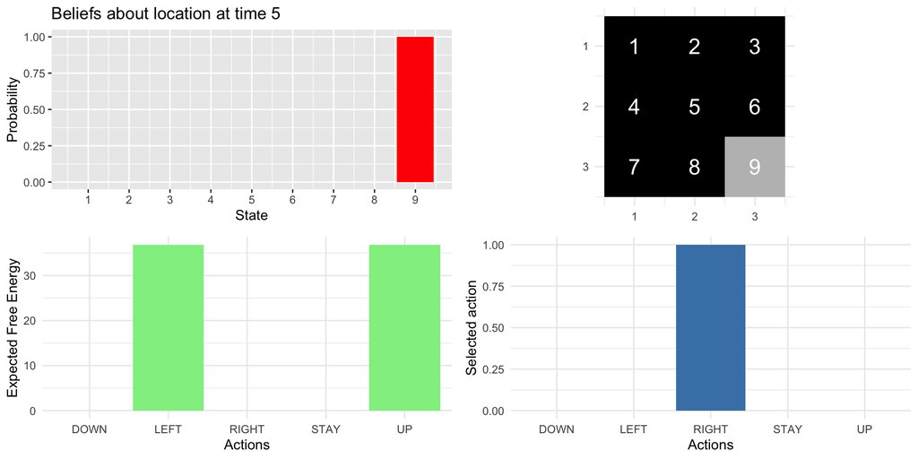

## プランニング

- 開始位置を１にすると、５試行では位置９まで到達しない(`env <- GridWorldEnv$new(starting_state = c(1,1))`で実行すると確認できる)
- これまで実行した設定では各行為の期待自由エネルギーGを1タイムステップ先までしか評価していない。位置９から遠い位置ではアクションごとの期待自由エネルギーに差がなく、行動選択がランダムになる。
- プランニング、すなわち複数タイムステップを考慮したポリシーを設定すれば短い試行で位置９に到達する（実装がやや複雑なので今回は省略、詳細は[pymdpのチュートリアル](https://pymdp-rtd.readthedocs.io/en/latest/notebooks/active_inference_from_scratch.html#planning)参照）

## 能動的推論モデルの学習

- 生成モデル($\textbf{ABCD}$)を事前に設定してきたが、生成モデルはエージェントのモデルであって、生成過程のモデルではない。体験を通した生成モデルの変化（学習）を考える必要があることも。
- 生成モデルの尤度（$\textbf{A}$)と遷移行列（$\textbf{B}$)を経験を通して変化（学習）させることができる。
- $\textbf{A}$ や$\textbf{B}$などのパラメータに関する信念を設定して、その更新によって学習を実現できる。

**階層的推論（深層生成モデル）**

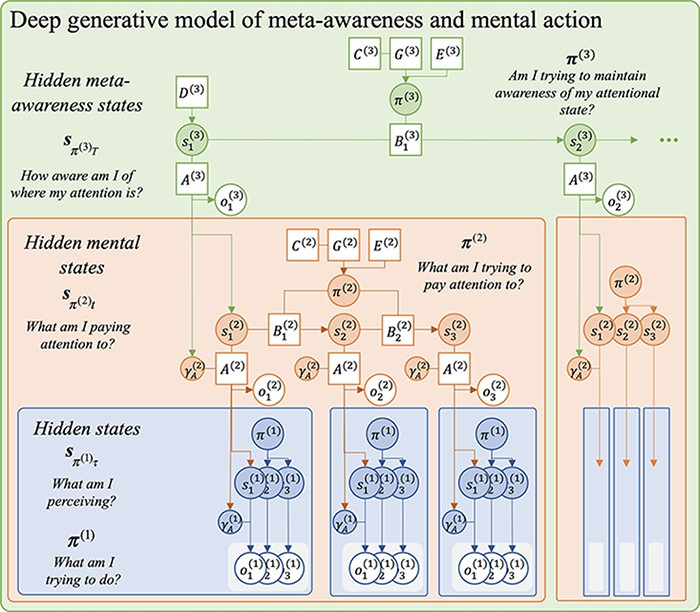

## 階層的推論（深層生成モデル）

- [Sandved-Smith and Hesp et al.(2011)](https://doi.org/10.1093/nc/niab018)のメタアウェアネスモデルの生成モデル
- 上の層は時間的にゆっくり変化
- 層が増えるほど複雑な現象のモデル化ができる

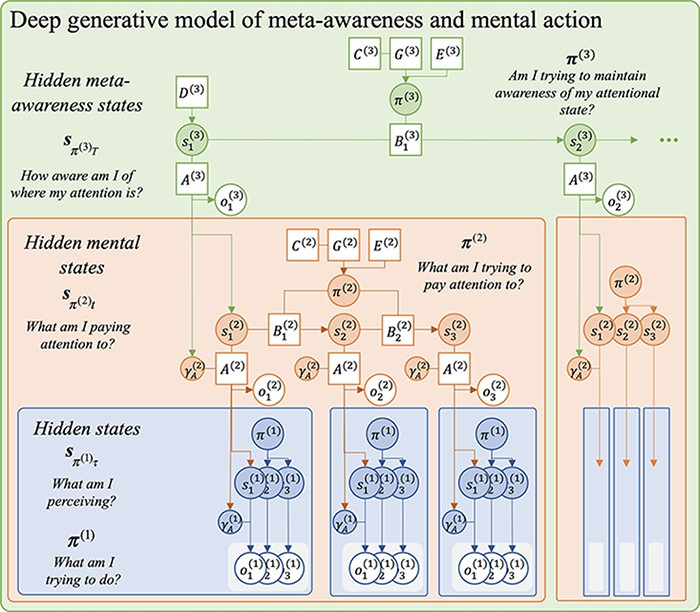

# 能動的推論研究の展開

## 能動的推論とパラメータ推定

- 能動的推論モデルについての理論やシミュレーション研究は非常に盛んに行われている
- 実際の行動データに能動的推論モデルを適用したパラメータ推定は研究がまだ少ない（すべてのパラメータを推定できないので、何を推定するのか設定するのが難しい）
- 能動的推論モデルが適用しやすい状況を設定し、推定するパラメータを上手に絞り込むことでパラメータ推定している研究もある。

**2段階強化学習課題**

- [Gillan et al.(2016)](https://elifesciences.org/articles/11305)は、[Daw et al.(2011)](https://pmc.ncbi.nlm.nih.gov/articles/PMC3077926/)の2段階強化学習課題で目標志向的コントロールと症状の関連を検討
- ステップ１の選択でステップ２に移行し（70か30％），ステップ２の選択に応じて報酬（報酬は確率変動する）

[figure not shown]

## モデルベースとモデルフリー

**モデルフリー**：ステップ２がCommonかrareかに関わらず、報酬がでたら次も同じステップ１の選択

**モデルベース**：ステップ２への遷移を考慮し、報酬がでたら、次はCommonなら同じステップ１を選択，Rareなら別のステップ１を選択

実際のデータからは、両モデルのハイドブリッドになっている

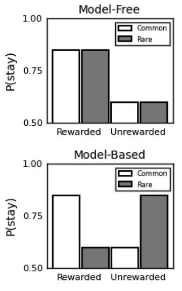

## 目標志向的コントロールと症状

- モデルベースな意思決定ができる＝目標志向的コントロールができる
- ２段階強化学習課題をオンライン実験し、目標志向的コントロールと症状の関連を検討（実験２の対象者は1413名）
- 摂食障害，衝動性，強迫，アルコール依存がモデルベース学習に有意な効果

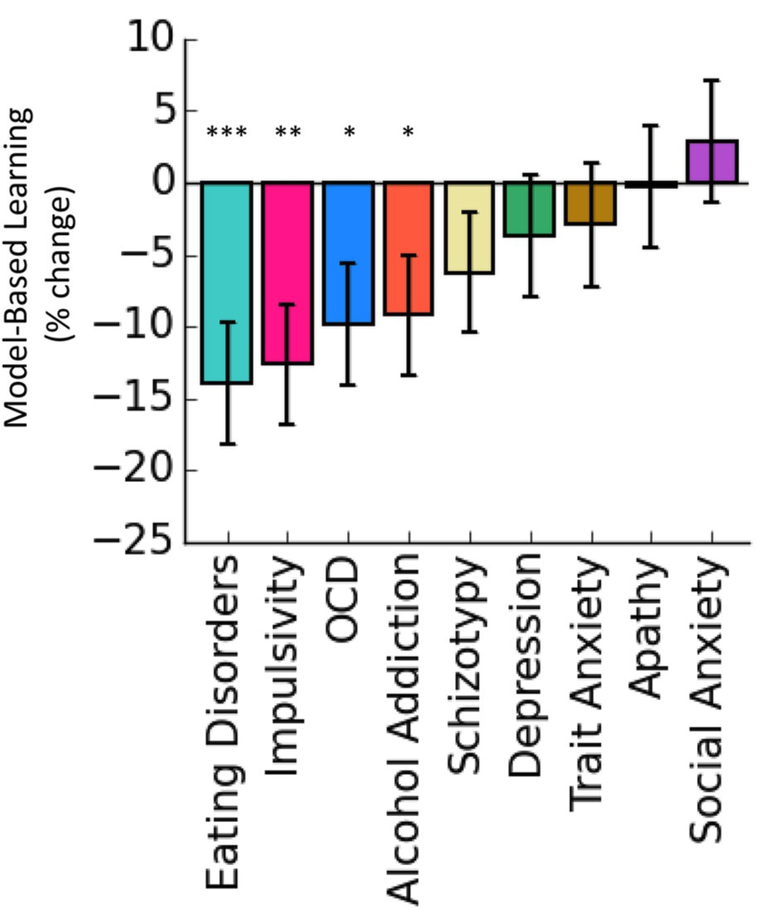

## 計算論的因子モデリング

- 計算論的因子モデリングでは、複数の症状尺度を因子分析して出てきた次元とモデルのパラメータとの関連を検討([Wise et al. ,2022](https://www.sciencedirect.com/science/article/pii/S0006322322016614))
- 不安-うつ，強迫行動-侵入思考，社会的ひきこもり次元が抽出され、強迫行動-侵入思考とモデルベースな程度が関連

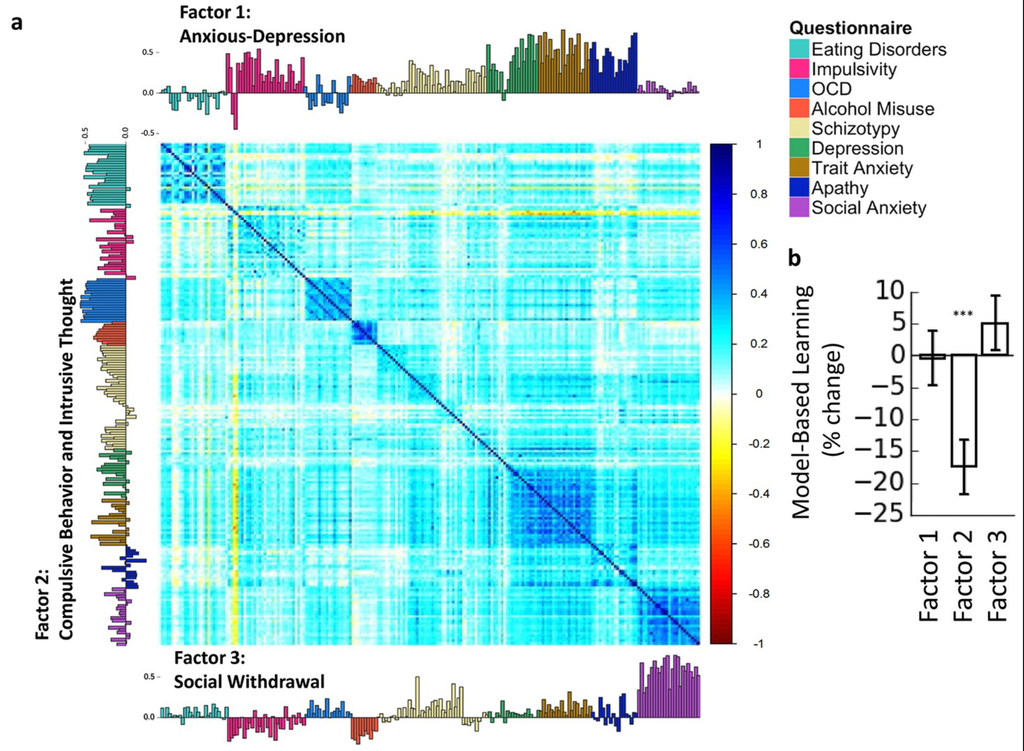

## 2段階強化学習課題での能動的推論

- [Gijsen et al.(2022)](https://www.nature.com/articles/s41598-022-21766-4#Sec16)は、2段階強化学習課題に能動的推論モデルを適用。状態遷移を考慮したベイズ推論＋期待自由エネルギーに基づく行動選択（報酬獲得な側面だけでなく、情報取得の側面も扱える）

→通常の強化学習モデルよりも、能動的推論モデルをいれたモデルのほうがデータフィットが良いケースもある。

→ABCD行列を設定したパラメータ推定も可能だが、Gijsen et al.(2022)のように、コンパクトにモデルを設定して、期待自由エネルギーによる行動選択を実装することも可能。

## 心理療法と能動的推論

- 能動的推論モデルを用いた心理療法の研究は、まだ始まったばかり。
- [Smith et al.(2021)](https://www.nature.com/articles/s41598-021-89047-0)は、クモ恐怖への認知行動療法の作用メカニズムのシミュレーションを行った。

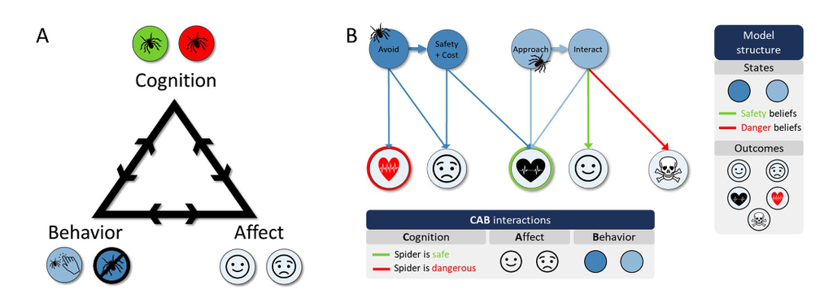

## 心理療法と能動的推論

- 顕在信念(言語化可能なもの)と潜在信念(信念・行動・結果の間の関係など）を分けて、心理的介入（認知再構成とエクスポージャー）のメカニズムを検討

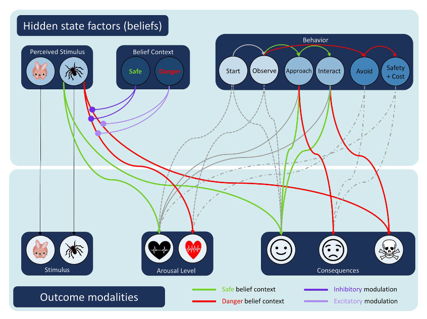

## 心理療法と能動的推論

- 認知再構成をしてからエクスポージャーすると、顕在信念では安全と評価するが、潜在信念(クモへの接近とポジティブ感情の関連)は変化しない

→ 潜在信念が変化してないので再発につながる？

- 顕在信念（クモの危険性）が高くも低くもない状態でエクスポージャーすると、潜在信念が変化した。

→ 不確実性を含んだ顕在信念の下でエクスポージャーすることが潜在信念の変容を促す可能性（マインドフルネスなどの思考距離をとる方略？）

## 能動的推論による心理療法の理解

- 自由エネルギー原理からマインドフルネスや精神分析について論じる論文や書籍も増えてきている(精神分析はHolmes(2020)が分かりやすい、マインドフルネスは国里・山本(2021)も）

→心理療法の統一的理解の枠組みにもなる？

- 能動的推論は、生成モデルから精神障害を理解するので、当事者の体験とも整合的な可能性がある。

→心理療法における心理教育での活用？

## まとめ

- 計算論的精神医学の生成モデルにベイズ推論モデルがあり、エージェントの生成モデルを検討している。ベイズ推論モデルは状態空間モデルから整理できる。
- 離散時間のPOMDP下での能動的推論は、生成過程（環境のモデル）と生成モデル（$\textbf{ABCD}$行列）を設定すれば、シミュレーションできる
- 生成モデルについて、プランニング、学習、階層化などを通してより複雑な現象も扱える。
- 能動的推論モデルを用いた臨床状況におけるシミュレーション研究やデータを用いたパラメータ推定研究も行われつつある。